# Case Study

BAK Donghui

Mar 13, 2022

### Abstract

This is the last module of Google Data Analytics Certificate. There are 6 steps in case study analytics which are ask, prepare, process, analyze, share, and act.  
Every data and business concept here is fiction and data is authorized by Google. Questions with bullet point are from google.

### Scenario

Customers who purchase single-ride or full-day passes are referred to as casual riders. Customers who purchase annual memberships are Cyclistic members.  
Cyclistic’s finance analysts have concluded that annual members are much more profitable than casual riders. Although the pricing flexibility helps Cyclistic attract more customers, Moreno believes that maximizing the number of annual members will be key to future growth. Rather than creating a marketing campaign that targets all-new customers, Moreno believes there is a very good chance to convert casual riders into members.  
Moreno has set a clear goal: Design marketing strategies aimed at converting casual riders into annual members. In order to do that, however, the marketing analyst team needs to better understand how annual members and casual riders differ, why casual riders would buy a membership, and how digital media could affect their marketing tactics. Moreno and her team are interested in analyzing the Cyclistic historical bike trip data to identify trends.

### Ask

- **What is the problem you are trying to solve?**  
  I am assigned to answer the question, how do annual members and casual riders use Cyclistic bikes differently? I will figure out key features which distinguish annual members and casual riders.
- **How can your insights drive business decisions?**  
  Data analyst is not a decision maker. Data analyst does analysis for helping stakeholders recognize currently statement of business clearly. There will be a great plus point if data analyst could suggest right recommendations.

### Prepare

- **Where is your data located?**  
  I have stored them in local drive.
- **How is the data organized?**  
  The data are csv format.
- **Are there issues with bias or credibility in this data? Does your data ROCCC(reliable, original, comprehensive, current and cited)?**  
  In the real world, ROCCC of the data is an issue.Since I am doing case study, I will reckon data are fine.
- **How are you addressing licensing, privacy, security, and accessibility?**  
  It is important to know property of data. Nonetheless engineers take control of data in the real world, data analyst should know legal issues of data, such as licensing, privacy, security, and so on.  
  Usually data stored in DB. This is why SQL is called basic skillset of data analyst.

### Process

- **What steps have you taken to ensure that your data is clean?**  
  OK. Let’s get down to business. Data preprosessing!!
1. Load libarary

```r
library(data.table)
library(dplyr)
```

```r
library(ggplot2)
library(finalfit)
library(tidyverse)
library(norm)
```

2. Load data

```r
# df <- read.csv("C:/Users/dhton/Desktop/google_case/data/202101-divvy-tripdata.csv", header=T)
# for (i in 2:12){
#   df_title <- sprintf("C:/Users/dhton/Desktop/google_case/data/2021%02d-divvy-tripdata.csv", i)
#   add_df <- read.csv(df_title, header=T)
#   df <- rbind(df, add_df)
# }

# It took time much more than I expected. The exact time is below.

# system.time(for (i in 2:12){
#   df_title <- sprintf("C:/Users/dhton/Desktop/google_case/data/2021%02d-divvy-tripdata.csv", i)
#   add_df <- read.csv(df_title, header=T)
#   df <- rbind(df, add_df)
# })
#  사용자  시스템 elapsed
#  104.88    2.50  107.69


# Maybe there is a better way.
N <- 12
file_list <- vector("list", N)
for (i in 1:N){
  file_name <- sprintf("C:/Users/dhton/Desktop/google_case/data/2021%02d-divvy-tripdata.csv", i)
  file_list[[i]] <- file_name
}
l <- lapply(file_list, fread, sep = ",")
# 사용자  시스템 elapsed
#   4.97    0.40    3.68
dt <- rbindlist(l)
# 사용자  시스템 elapsed
#   0.31    0.06    0.38

# Much better!!
```

```r
glimpse(dt)
```

```
## Rows: 5,595,063
## Columns: 13
## $ ride_id            <chr> "E19E6F1B8D4C42ED", "DC88F20C2C55F27F", "EC45C94683~
## $ rideable_type      <chr> "electric_bike", "electric_bike", "electric_bike", ~
## $ started_at         <dttm> 2021-01-23 16:14:19, 2021-01-27 18:43:08, 2021-01-~
## $ ended_at           <dttm> 2021-01-23 16:24:44, 2021-01-27 18:47:12, 2021-01-~
## $ start_station_name <chr> "California Ave & Cortez St", "California Ave & Cor~
## $ start_station_id   <chr> "17660", "17660", "17660", "17660", "17660", "17660~
## $ end_station_name   <chr> "", "", "", "", "", "", "", "", "", "Wood St & Augu~
## $ end_station_id     <chr> "", "", "", "", "", "", "", "", "", "657", "13258",~
## $ start_lat          <dbl> 41.90034, 41.90033, 41.90031, 41.90040, 41.90033, 4~
## $ start_lng          <dbl> -87.69674, -87.69671, -87.69664, -87.69666, -87.696~
## $ end_lat            <dbl> 41.89000, 41.90000, 41.90000, 41.92000, 41.90000, 4~
## $ end_lng            <dbl> -87.72000, -87.69000, -87.70000, -87.69000, -87.700~
## $ member_casual      <chr> "member", "member", "member", "member", "casual", "~
```

There are 13 variables in data. Since I do not have meta data, I should investigate variables and guess they mean.(Obviously, do not try this at the real world. Ask data engineer)

ride_id

```r
glimpse(unique(dt$ride_id))
```

```
##  chr [1:5595063] "E19E6F1B8D4C42ED" "DC88F20C2C55F27F" "EC45C94683FE3F27" ...
```

`ride_id` seems be generated randomly and unique by single ride, which makes hard to recognize return user.

I can guess others by their names but `start_lat`, `start_lng`, `end_lat`, `and end_lng`.

```r
dt[, 9:12] %>% summary()
```

```
##    start_lat       start_lng         end_lat         end_lng
##  Min.   :41.64   Min.   :-87.84   Min.   :41.39   Min.   :-88.97
##  1st Qu.:41.88   1st Qu.:-87.66   1st Qu.:41.88   1st Qu.:-87.66
##  Median :41.90   Median :-87.64   Median :41.90   Median :-87.64
##  Mean   :41.90   Mean   :-87.65   Mean   :41.90   Mean   :-87.65
##  3rd Qu.:41.93   3rd Qu.:-87.63   3rd Qu.:41.93   3rd Qu.:-87.63
##  Max.   :42.07   Max.   :-87.52   Max.   :42.17   Max.   :-87.49
##                                   NA's   :4771    NA's   :4771
```

I do not have any idea what they are.They will not be used.

```r
dt[, 9:12 := NULL]
```

I can see that there are blanks in `end_station_name` and `end_station_id`. Maybe NULL and blanks are mixed in this data.

3. Check NULL(or blank)

```r
# dt1[, lapply(dt1[,c(1:2, 5:8)], function(x) sum(x == ""))]
# Above code type is little bit slower than below type
dt[, lapply(.SD, function(x) sum(x=="")), .SDcols = c(1:2, 5:8)]
```

```
##    ride_id rideable_type start_station_name start_station_id end_station_name
## 1:       0             0             690809           690806           739170
##    end_station_id
## 1:         739170
```

```r
# POSIXct class can't compare with charactere
dt[, sapply(.SD, function(x) sum(as.character(x)=="")), .SDcols = 3:4]
```

```
## started_at   ended_at
##          0          0
```

```r
# It takes a bit long time..
dt[, lapply(.SD, function(x) sum(is.na(x)))]
```

```
##    ride_id rideable_type started_at ended_at start_station_name
## 1:       0             0          0        0                  0
##    start_station_id end_station_name end_station_id member_casual
## 1:                0                0              0             0
```

```r
# is.na doesn't have to assign SDcols.
```

NULL in `start_station_name`, `start_station_id`, `end_station_id`, and `end_station_name` are more than 10%, which is little too much. It’s time to handle missing value.

4. Missing value  
   It would be easier to use many NULL handling packages in R if I change blanks to NULL.

```r
# dt2 <- mutate_all(dt1[,-(3:4)], list(~na_if(.,"")))
# below is faster
dt1 <- dt[, lapply(.SD, function(x) na_if(x, "")), .SDcols = -(3:4)]
# POSIXlt class is irritate to convert.
```

I want to check variables in detail.

```r
dt1 %>% select(3:6) %>% ff_glimpse()
```

```
## $Continuous
## Null data.table (0 rows and 0 cols)
##
## $Categorical
##                                 label var_type       n missing_n
## start_station_name start_station_name    <chr> 4904254    690809
## start_station_id     start_station_id    <chr> 4904257    690806
## end_station_name     end_station_name    <chr> 4855893    739170
## end_station_id         end_station_id    <chr> 4855893    739170
##                    missing_percent levels_n levels levels_count levels_percent
## start_station_name            12.3      847      -            -              -
## start_station_id              12.3      834      -            -              -
## end_station_name              13.2      844      -            -              -
## end_station_id                13.2      832      -            -              -
```

Visualization will be helpful for better understanding.

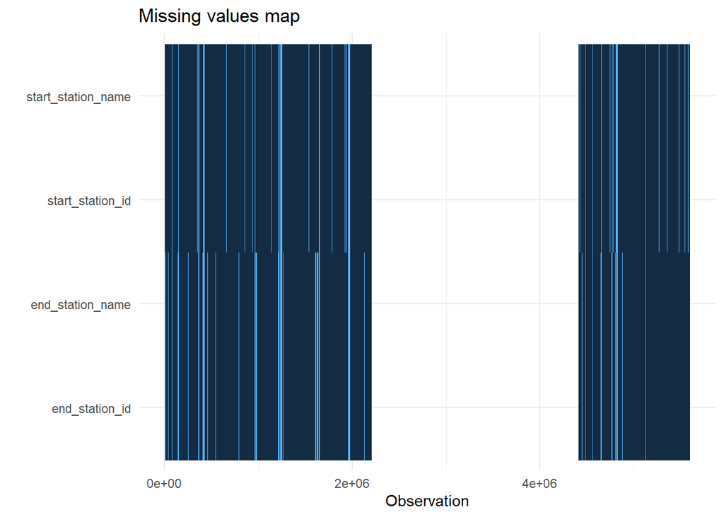

```r
dt1 %>% select(3:6) %>% missing_plot()
```

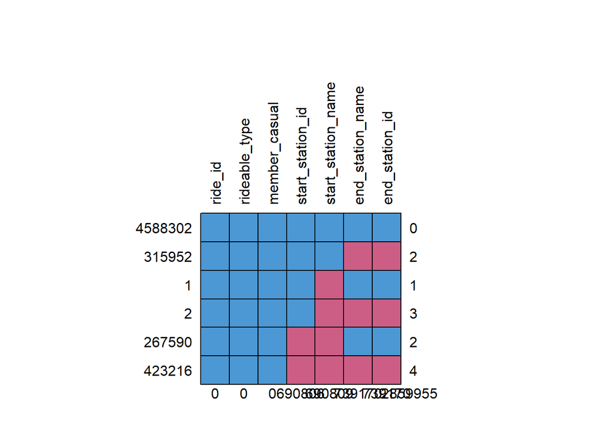

```
##         ride_id rideable_type member_casual start_station_id start_station_name
## 4588302       1             1             1                1                  1
## 315952        1             1             1                1                  1
## 1             1             1             1                1                  0
## 2             1             1             1                1                  0
## 267590        1             1             1                0                  0
## 423216        1             1             1                0                  0
##               0             0             0           690806             690809
##         end_station_name end_station_id
## 4588302                1              1       0
## 315952                 0              0       2
## 1                      1              1       1
## 2                      0              0       3
## 267590                 1              1       2
## 423216                 0              0       4
##                   739170         739170 2859955
```

```r
dt1 %>% missing_pattern()
```

Before the imputation, I should know what type of missing value they are. If they are MACR or MAR, it would be pretty easy to impute.  
As far as I know, Little’s test is commonly used for MCAR test of categorical value. Thanks to Eric Stemmler, below codes are quoted.

```r
mcar <- function(x){
  if(!require(norm)) {
    stop("You must have norm installed to use LittleMCAR")
  }

  # if(!require(data.table)) {
  #     stop("Please install the R-package data.table to use mcar")
  # }

  if(!(is.matrix(x) | is.data.frame(x))) {
    stop("Data should be a matrix or dataframe")
  }

  if (is.data.frame(x)){
    x <- data.matrix(x)
  }

  # delete rows of complete missingness
  foo <- function(x) return(any(!is.na(x)))
  dd <- apply(X = x, MARGIN = 1L, FUN = foo)
  dd <- which(!dd, arr.ind = TRUE)
  if(length(dd) > 0)
    x <- x[-dd,]

  # define variables
  n.var <- ncol(x) # number of variables
  n <- nrow(x)  #number of respondents
  var.names <- colnames(x)
  r <- 1 * is.na(x)

  nmis <- as.integer(apply(r, 2, sum))  #number of missing data for each variable REWRITE
  mdp <- (r %*% (2^((1:n.var - 1)))) + 1  #missing data patterns
  x.mp <- data.frame(cbind(x,mdp)) # add column indicating pattern
  colnames(x.mp) <- c(var.names,"MisPat") # set name of new column to MisPat
  n.mis.pat <- length(unique(x.mp$MisPat)) # number of missing data patterns
  p <- n.mis.pat-1 # number of Missing Data patterns minus 1 (complete data row)


  s <- prelim.norm(x)
  ll <- em.norm(s)
  fit <- getparam.norm(s = s, theta = ll)

  # gmean<-mlest(x)$muhat #ML estimate of grand mean (assumes Normal dist)
  gmean <- fit$mu
  # gcov<-mlest(x)$sigmahat #ML estimate of grand covariance (assumes Normal dist)
  gcov <- fit$sigma
  colnames(gcov) <- rownames(gcov) <- colnames(x)

  #recode MisPat variable to go from 1 through n.mis.pat
  x.mp$MisPat2 <- rep(NA,n)
  for (i in 1:n.mis.pat){
    x.mp$MisPat2[x.mp$MisPat == sort(unique(x.mp$MisPat), partial=(i))[i]]<- i
  }

  x.mp$MisPat<-x.mp$MisPat2
  x.mp<-x.mp[ , -which(names(x.mp) %in% "MisPat2")]

  #make list of datasets for each pattern of missing data
  datasets <- list()
  for (i in 1:n.mis.pat){
    datasets[[paste("DataSet",i,sep="")]]<-x.mp[which(x.mp$MisPat==i),1:n.var]
  }

  #degrees of freedom
  kj<-0
  for (i in 1:n.mis.pat){
    no.na<-as.matrix(1* !is.na(colSums(datasets[[i]])))
    kj<-kj+colSums(no.na)
  }

  df<-kj -n.var

  #Little's chi-square
  d2<-0
  cat("this could take a while")

  # this crashes at the missingness pattern where every column is missing
  # this for-loop can be handled faster with plyr-function
  for (i in 1:n.mis.pat){
    mean <- (colMeans(datasets[[i]])-gmean)
    mean <- mean[!is.na(mean)]
    keep <- 1* !is.na(colSums(datasets[[i]]))
    keep <- keep[which(keep[1:n.var]!=0)]
    cov <- gcov
    cov <- cov[which(rownames(cov) %in% names(keep)) , which(colnames(cov) %in% names(keep))]
    d2 <- as.numeric(d2+(sum(x.mp$MisPat==i)*(t(mean)%*%solve(cov)%*%mean)))
  }

  #p-value for chi-square
  p.value<-1-pchisq(d2,df)

  #descriptives of missing data
  amount.missing <- matrix(nmis, 1, length(nmis))
  percent.missing <- amount.missing/n
  amount.missing <- rbind(amount.missing,percent.missing)
  colnames(amount.missing) <- var.names
  rownames(amount.missing) <- c("Number Missing", "Percent Missing")

  list(chi.square = d2,
       df = df,
       p.value = p.value,
       missing.patterns = n.mis.pat,
       amount.missing = amount.missing,
       data = datasets)
}
```

Before I use Little’s test, I should reduce level of `start_station_name` and `end_station_name`. It is not only for Little’s test, but also to avoid curse of dimension.

```r
dt1[, c(4,6) := NULL]
dt1$start_station_big_name <- as.character(lapply(strsplit(as.character(dt1$start_station_name), split = '&'), "[",1))
dt1$end_station_big_name <- as.character(lapply(strsplit(as.character(dt1$end_station_name), split = '&'), "[",1))
dt1[, 3:4 := NULL]
```

Let’s check how many levels I have.

```r
dt1%>% select(4:5) %>% ff_glimpse()
```

```
## $Continuous
## Null data.table (0 rows and 0 cols)
##
## $Categorical
##                                         label var_type       n missing_n
## start_station_big_name start_station_big_name    <chr> 4904254    690809
## end_station_big_name     end_station_big_name    <chr> 4855893    739170
##                        missing_percent levels_n levels levels_count
## start_station_big_name            12.3      335      -            -
## end_station_big_name              13.2      333      -            -
##                        levels_percent
## start_station_big_name              -
## end_station_big_name                -
```

Much better! But still they are too many. However, there is no way to categorise into larger group unless I apply advanced statistics. It is time to admit my limitation and do Little’s test.

```r
r <- mcar(dt1[,c(2:5)])
```

```
## Iterations of EM:
## 1...2...3...4...5...
## this could take a while
```

```r
r[["p.value"]]
```

```
## [1] 0
```

```r
r[["missing.patterns"]]
```

```
## [1] 4
```

```r
r[["amount.missing"]]
```

```
##                 rideable_type member_casual start_station_big_name
## Number Missing              0             0           6.908090e+05
## Percent Missing             0             0           1.234676e-01
##                 end_station_big_name
## Number Missing          7.391700e+05
## Percent Missing         1.321111e-01
```

Oops..Maybe `start_station_big_name` and `end_station_big_name` is too related? Let’s try not to put them together.

```r
r1 <- mcar(dt1[,c(2:4)])
```

```
## Iterations of EM:
## 1...2...3...4...5...
## this could take a while
```

```r
r1[["p.value"]]
```

```
## [1] 0
```

```r
r1[["missing.patterns"]]
```

```
## [1] 2
```

```r
r1[["amount.missing"]]
```

```
##                 rideable_type member_casual start_station_big_name
## Number Missing              0             0           6.908090e+05
## Percent Missing             0             0           1.234676e-01
```

Hmm..p value is still 0. Maybe it is because levels of variables are too many or `rideable_type` or `member_casual` is criminal.

```r
dt1 %>% filter(is.na(start_station_big_name))  %>% distinct(rideable_type,member_casual)
```

```
##    rideable_type member_casual
## 1: electric_bike        member
## 2: electric_bike        casual
```

```r
dt1[is.na(dt1$end_station_big_name),] %>% distinct(rideable_type,member_casual)
```

```
##    rideable_type member_casual
## 1: electric_bike        member
## 2: electric_bike        casual
## 3:  classic_bike        member
## 4:  classic_bike        casual
## 5:   docked_bike        casual
```

Aha! Only `electric_bike` is missing on `start_station_big_name` and only `docked_bike` by `member` is not missing on `end_station_big_name`.

5. Imputation  
   Since the missing data are not MCAR, I cannot delete them. I can see that there are some missing patterns so I will impute them by mode imputation. I know there is limitation on mode imputation, but I do not want to use advanced imputation method since I do not fully understand their formulars.  
   I will impute from `start_station_big_name`. I found some handy function for calculating mode.

```r
calc_mode <- function(x){

  # List the distinct / unique values
  distinct_values <- unique(x)

  # Count the occurrence of each distinct value
  distinct_tabulate <- tabulate(match(x, distinct_values))

  # Return the value with the highest occurrence
  distinct_values[which.max(distinct_tabulate)]
}
```

```r
df_afimp <- dt1 %>% group_by(rideable_type, member_casual) %>%
  mutate(start_station_big_name = if_else(is.na(start_station_big_name),
                                          calc_mode(dt1[!is.na(start_station_big_name)]$start_station_big_name),
                                          start_station_big_name))

dt_afimp <- data.table(df_afimp)
dt_afimp[, .N, .(start_station_big_name)][order(-N)]
```

```
##               start_station_big_name       N
##   1:                       Clark St  1069017
##   2:                       Wells St   190151
##   3:                   Michigan Ave   186739
##   4:                       Broadway   157246
##   5:                     Halsted St   131216
##  ---
## 331:                   Shabbona Park       2
## 332:  Throop/Hastings Mobile Station       2
## 333:                   N Hampden Ct        1
## 334: Lyft Driver Center Private Rack       1
## 335:            Olive Harvey College       1
```

Well, I can see all `NA` change into `Clark St`. I think it is too exaggerate, but let’s move on.

Imputation of `end_station_big_name`.

```r
df_afimp1 <- dt_afimp %>% group_by(rideable_type, member_casual) %>%
  mutate(end_station_big_name = if_else(is.na(end_station_big_name),
                                        calc_mode(dt1[!is.na(end_station_big_name)]$end_station_big_name),
                                        end_station_big_name))

dt_afimp1 <- data.table(df_afimp1)
dt_afimp1[, .N, .(end_station_big_name)][order(-N)]
```

```
##                 end_station_big_name       N
##   1:                       Clark St  1112796
##   2:                       Wells St   186988
##   3:                   Michigan Ave   184094
##   4:                       Broadway   157199
##   5:                     Halsted St   130363
##  ---
## 329:                   Shabbona Park       2
## 330:                     Whipple St        2
## 331:                   N Hampden Ct        1
## 332: Lyft Driver Center Private Rack       1
## 333:  Throop/Hastings Mobile Station       1
```

6. Create variables  
   Riding time and riding day can be calculated. I will create variables after paste time information that I cut.

```r
dt2 <- cbind(dt_afimp1,dt[,3:4])
dt3 <- dt2 %>% mutate(ride_length = round(as.numeric(ended_at - started_at, units='mins')), weekday = weekdays(started_at))
```

Is new variable OK?

```r
dt3[,.N,weekday]
```

```
##    weekday      N
## 1:  토요일 991047
## 2:  수요일 756142
## 3:  목요일 737588
## 4:  월요일 702588
## 5:  일요일 857285
## 6:  금요일 810508
## 7:  화요일 739905
```

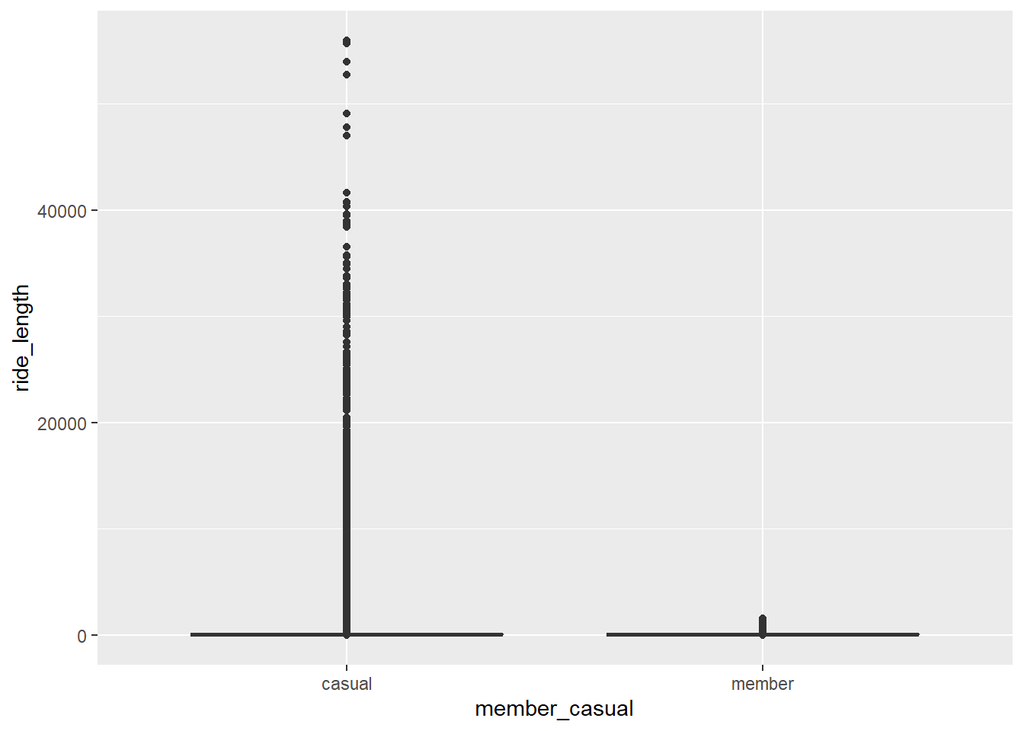

```r
ggplot(data=dt3, aes(x=member_casual, y=ride_length)) +
  geom_boxplot()
```

`ride_length` seems strange. I will check quantile.

```r
dt3 %>% group_by(member_casual) %>%
  summarize('0%' = quantile(ride_length, probs=0),
            '25%' = quantile(ride_length, probs=0.25),
            '50%' = quantile(ride_length, probs=0.5),
            '75%' = quantile(ride_length, probs=0.75),
            '100%' = quantile(ride_length, probs=1))
```

```
## # A tibble: 2 x 6
##   member_casual  `0%` `25%` `50%` `75%` `100%`
##   <chr>         <dbl> <dbl> <dbl> <dbl>  <dbl>
## 1 casual          -58     9    16    29  55944
## 2 member          -54     6    10    17   1560
```

Hmm..After 75%, the number arose dramatically. It is strange that people ride bikes over 50000 mins and minus mins. Probably there were some computational or human error. The problem is, how do I distinguish which one is an error and which one is not.

The negative values are probably errors. But what about exaggerated values? Are they errors or outliers? I do not know at this moment. Thus, I will just change negative values to median(not mean since there are many exaggerated values)

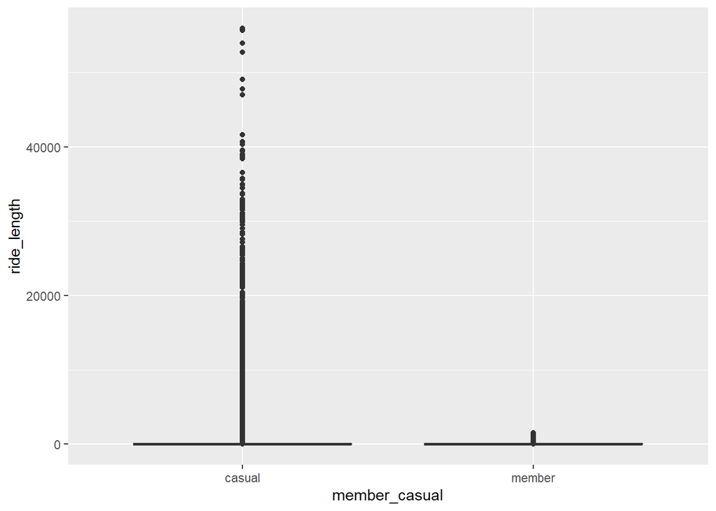

```r
dt3[, ride_length := ifelse(ride_length<0, median(ride_length), ride_length)]
ggplot(data=dt3, aes(x=member_casual, y=ride_length)) +
  geom_boxplot()
```

It would be better if there is larger category regarding `ride_length`

```r
dt3[, big_ride_length := ifelse(ride_length < 30, 'Less 30mins',
                                ifelse(ride_length <= 60, 'Half~1hour',
                                ifelse(ride_length <= 90, '1~1.5hours',
                                ifelse(ride_length <= 120, '1.5~2hours',
                                'More 2hours'))))]
```

This is the summary.

```r
glimpse(dt3)
```

```
## Rows: 5,595,063
## Columns: 10
## $ ride_id                <chr> "E19E6F1B8D4C42ED", "DC88F20C2C55F27F", "EC45C9~
## $ rideable_type          <chr> "electric_bike", "electric_bike", "electric_bik~
## $ member_casual          <chr> "member", "member", "member", "member", "casual~
## $ start_station_big_name <chr> "California Ave ", "California Ave ", "Californ~
## $ end_station_big_name   <chr> "Clark St ", "Clark St ", "Clark St ", "Clark S~
## $ started_at             <dttm> 2021-01-23 16:14:19, 2021-01-27 18:43:08, 2021~
## $ ended_at               <dttm> 2021-01-23 16:24:44, 2021-01-27 18:47:12, 2021~
## $ ride_length            <dbl> 10, 4, 1, 12, 1, 54, 6, 7, 3, 7, 5, 10, 9, 10, ~
## $ weekday                <chr> "토요일", "수요일", "목요일", "목요일", "토요일~
## $ big_ride_length        <chr> "Less 30mins", "Less 30mins", "Less 30mins", "L~
```

### Analyze

- **What surprises did you discover in the data**  
  I guess member users ride bike more often and longer. However, since the ride_id are not generated per user, it is very difficult to count frequency of each user. Hence, I will focus on riding time.

```r
dt3 %>% group_by(member_casual) %>% summarise(mean(ride_length))
```

```
## # A tibble: 2 x 2
##   member_casual `mean(ride_length)`
##   <chr>                       <dbl>
## 1 casual                       32.0
## 2 member                       13.6
```

Surprisingly, casual riders use far much longer. It is because there are huge outliers(or errors), Let’s visualize with larger category.

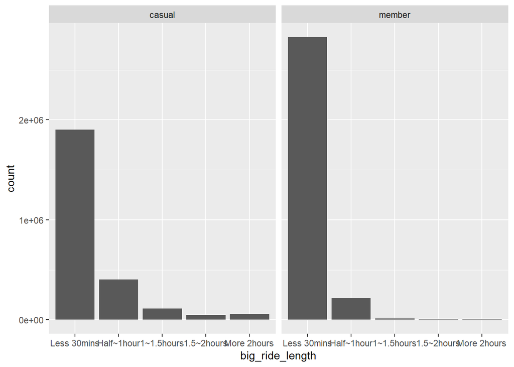

```r
dt3$big_ride_length <- ordered(dt3$big_ride_length,
                       levels=c('Less 30mins','Half~1hour','1~1.5hours','1.5~2hours','More 2hours'))
ggplot(dt3, aes(x=big_ride_length)) + geom_bar(stat='count') + facet_wrap(~member_casual)
```

It shows that **The members riding time is biased on ‘less than 30mins’ rather than casual’s**

Let’s check about weekday.

```r
table(dt3$weekday) %>% sort(decreasing = TRUE)
```

```
##
## 토요일 일요일 금요일 수요일 화요일 목요일 월요일
## 991047 857285 810508 756142 739905 737588 702588
```

I want to see whether member and casual show different weekday usage trend.

```r
# There are 3 ways of how to aggregate data by types.
# 1.Base R: table -> data.frame -> colnmaes()
#  > data.frame(table(dt1$weekday))
# 2.dplyr: using %>%
#  > dt1 %>% group_by(weekday) %>% summarise(cnt=n())
# 3.data.table: simple and fast
#  > dt1[, .N, weekday]
dt3[, .N, .(member_casual, weekday)][order(-member_casual, -N)]
```

```
##     member_casual weekday      N
##  1:        member  수요일 477192
##  2:        member  화요일 465513
##  3:        member  목요일 451524
##  4:        member  금요일 446428
##  5:        member  토요일 433047
##  6:        member  월요일 416212
##  7:        member  일요일 376142
##  8:        casual  토요일 558000
##  9:        casual  일요일 481143
## 10:        casual  금요일 364080
## 11:        casual  월요일 286376
## 12:        casual  목요일 286064
## 13:        casual  수요일 278950
## 14:        casual  화요일 274392
```

The result shows that member usually ride on weekdays and casual usually ride on weekends.  
Visualization will help to understand easier.

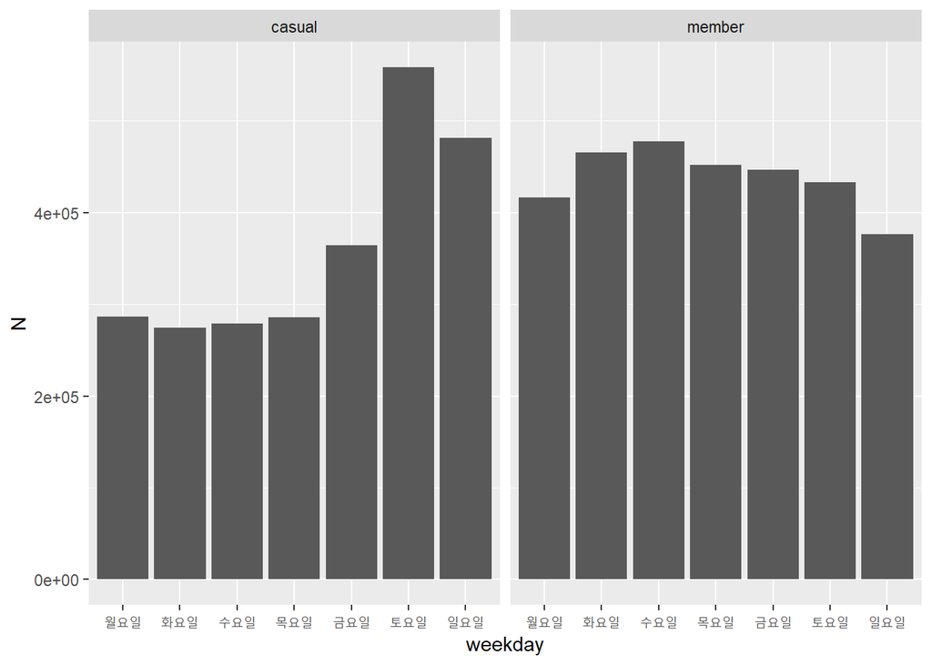

```r
# There are 2 ways of arrange weekday.
# 1.Create new row which translate weekday to int.
#  > dt1[, ':='(weekday_num, fcase(weekday == '월요일', 1,
                       # weekday == '화요일', 2,
                       # weekday == '수요일', 3,
                       # weekday == '목요일', 4,
                       # weekday == '금요일', 5,
                       # weekday == '토요일', 6,
                       # weekday == '일요일', 7))]

# 2. Input order to weekday value
#  > dt1$weekday <- ordered(dt3$weekday,
#                       levels=c('월요일','화요일','수요일','목요일','금요일','토요일','일요일' ))
# Second is better.

dt3$weekday <- ordered(dt3$weekday,
                      levels=c('월요일','화요일','수요일','목요일','금요일','토요일','일요일' ))
weekday_plot <- dt3[, .N, .(member_casual, weekday)][order(-member_casual, weekday)]
ggplot(weekday_plot, aes(x=weekday, y=N)) + geom_bar(stat='identity') + facet_wrap(~member_casual)
```

Let’s check about bike type.

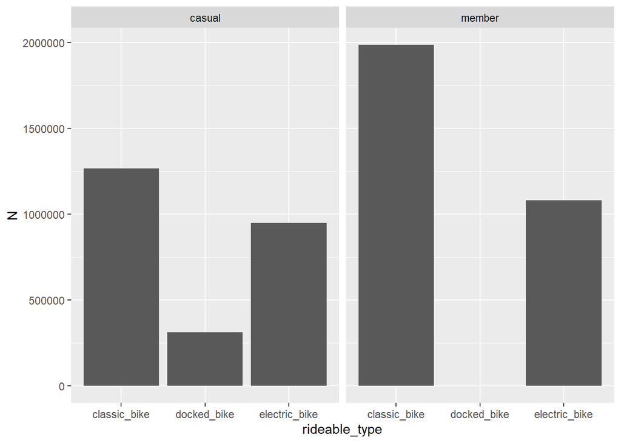

```r
rideable_plot <- dt3[, .N, .(member_casual, rideable_type)][order(-member_casual, rideable_type)]
ggplot(rideable_plot, aes(x=rideable_type, y=N)) + geom_bar(stat='identity') + facet_wrap(~member_casual)
```

It shows that **member do not use docked bike**.

What about stations? Is there any difference about station usage between the members and casuals? Should I see the difference of number or trend?

```r
dt3[,.N,.(member_casual)]
```

```
##    member_casual       N
## 1:        member 3066058
## 2:        casual 2529005
```

The members are about 20% more than the casuals. I think it is OK to compare them by numbers.

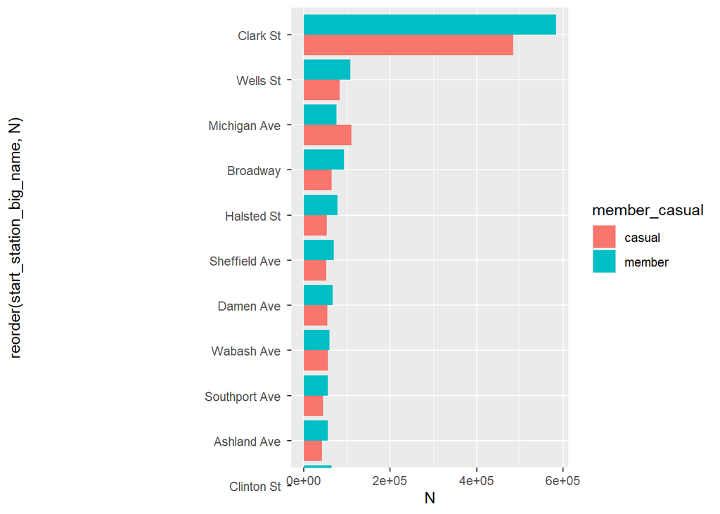

```r
ggplot(dt3[,.N,.(start_station_big_name, member_casual)], aes(x=reorder(start_station_big_name,N), y=N, fill=member_casual)) +
  geom_bar(stat='identity', position = position_dodge()) +
  coord_flip(xlim = c(length(unique(dt3$start_station_big_name))-9,
                      length(unique(dt3$start_station_big_name))))
```

In start station, the casuals ride more than members in`Michigan Ave`.

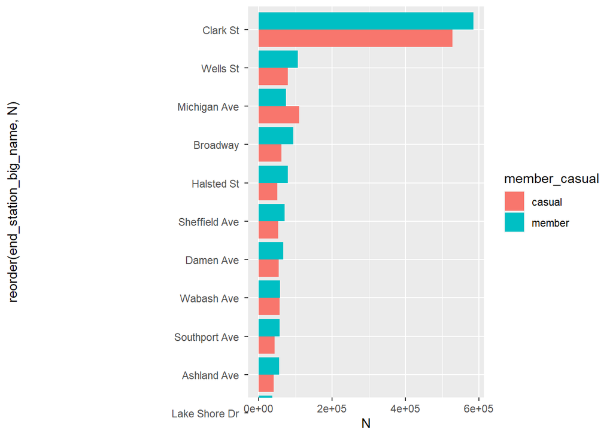

```r
ggplot(dt3[,.N,.(end_station_big_name, member_casual)], aes(x=reorder(end_station_big_name,N), y=N, fill=member_casual)) +
  geom_bar(stat='identity', position = position_dodge()) +
  coord_flip(xlim = c(length(unique(dt3$end_station_big_name))-9,
                      length(unique(dt3$end_station_big_name))))
```

There is no big difference of usage between `start_station_big_name` and `end_station_big_name`.

Why there is no big difference between start and end station? Are they ride within same location?

```r
dt3[, same_station := (start_station_big_name == end_station_big_name)]
number <- dt3[, .N, .(same_station, member_casual)][order(-member_casual, -same_station)]
number[, per := prop.table(N), member_casual]
number
```

```
##    same_station member_casual       N       per
## 1:         TRUE        member  516603 0.1684909
## 2:        FALSE        member 2549455 0.8315091
## 3:         TRUE        casual  549301 0.2172004
## 4:        FALSE        casual 1979704 0.7827996
```

About 20% of rides are occurred in same location. Interestingly, **the members rides more inter-location than the casuals**. It solids my opinion which **the members would ride for commuting**.

### Share

- **Where you able to answer the question of how annual members and casual riders use Cyclist bikes differently?**  
  The main purpose of members using the Cyclist is for commuting whilst the casuals’ is for entertaining.